# HW1_QA

Haotian Zhang and APPETI YAO Wateba

2020/11/16

## import libraries

```r
library(igraph)
library(sdpt3r)
library(Rlab)
```

## generate a random undirected graph

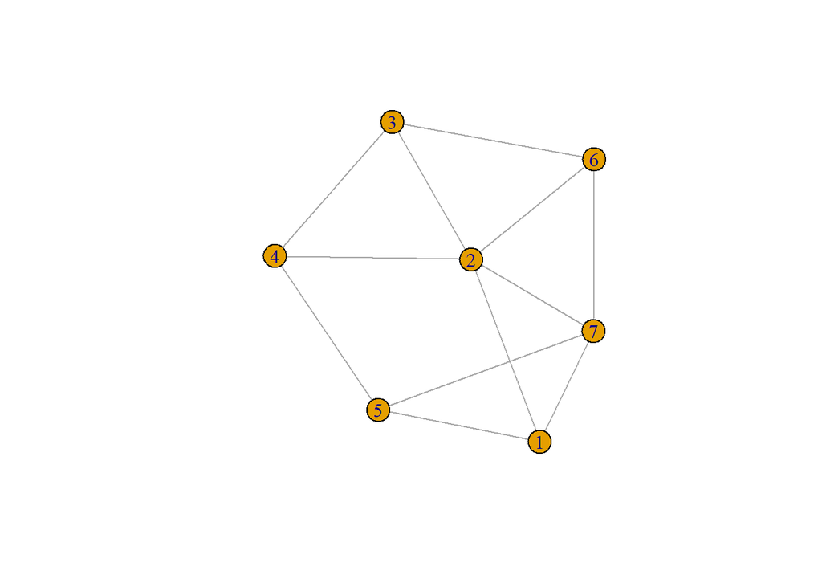

```r
B<-erdos.renyi.game(7,1/2)
plot(B)
```

## Show the Graph’s all vertices and edges

```r
V(B) #vertices
```

```
## + 7/7 vertices, from eb7fb33:
## [1] 1 2 3 4 5 6 7
```

```r
E(B) #edges
```

```
## + 12/12 edges from eb7fb33:
##  [1] 1--2 2--3 2--4 3--4 1--5 4--5 2--6 3--6 1--7 2--7 5--7 6--7
```

```r
G <- as.matrix(as_adjacency_matrix(B))
out<- maxcut(G)
maxcut <- abs(out$pobj)
maxcut
```

```
## [1] 9.457683
```

## Randomized Max-Cut Algorithm proposed by Paul Erdos

Create U as a random subset of V ; that is, for each vertex v belong to V , flip a fair coin: if Heads, add v to U otherwise do not.

From the algorithm, we can know that the probability that add v to U obeys to the Bernoulli distribution,so X={add v to U}~Ber(1,0.5).

```r
# rbern(n,prob): Random Sample From Bernoulli Distribution
Subset <- function(a,b){
  U<-c()
  for(k in 1:b){
    rand <- rbern(1,0.5)
    if(rand==1)
      U<-append(U,a[k])
  }
  return(U)
}
#as_ids:Convert Graph B To An Ordinary Vector
#gsize:number of edges of B
a <- as_ids(V(B))
U <-Subset(a,gsize(B))
U
```

```
## [1]  1  2  3  7 NA NA NA
```

### Evaluate the average cut-size over these M simulations and compare it with the theoretical bound opt(G)/2.

step1: get the edge of G and create the $\delta$ set.

```r
#lower.tri: returns a matrix of logicals the same size of a given matrix with entries TRUE in the lower or upper triangle.
G[lower.tri(G,diag=FALSE)] <-0
e<- which(G==1,arr.ind = TRUE)
colnames(e) <-c("u","v")
e
```

```
##       u v
##  [1,] 1 2
##  [2,] 2 3
##  [3,] 2 4
##  [4,] 3 4
##  [5,] 1 5
##  [6,] 4 5
##  [7,] 2 6
##  [8,] 3 6
##  [9,] 1 7
## [10,] 2 7
## [11,] 5 7
## [12,] 6 7
```

step2:create subset U and return its edges’ number $\delta u=\{\{u,v\}\in E such\ that\ u\in U\ and\ v\notin U\}$

```r
EdgeNum <-function(U,e){
  edges<-c()
  for(row in 1:nrow(e)){
    if((e[row,1] %in% U) && (!(e[row,2] %in% U))){
      edges <- append(edges, c(e[row,1],e[row,2]))
    }
  }
  return(length(edges))
}
```

step3:evaluate the average cut size over the M simulations

```r
averageCutSize <- function(a,e,M){
  avg.cutsize<-c()
  for(i in 1:M){
    U<-Subset(a,length(a))
    card.u<-EdgeNum(U,e)
    avg.cutsize<-append(avg.cutsize,card.u)
  }
  return(mean(avg.cutsize))
}
```

step4:compare the average cut size with OPT(G)/2

```r
card <- averageCutSize(a,e ,1000)
Truecard <- maxcut/2
card
```

```
## [1] 6.006
```

```r
Truecard
```

```
## [1] 4.728841
```

```r
card >= Truecard
```

```
## [1] TRUE
```

*From the result, we can know that the expected size of the cut set determined by U is at least opt/2.*

## Repeat the previous algorithm and increase the size of Graph to observation if somenthing is changed

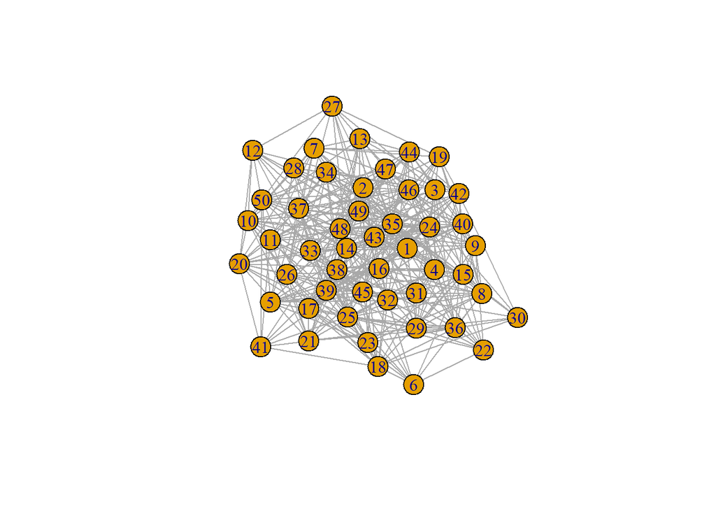

```r
C <- erdos.renyi.game(50,1/3)
plot(C)
```

```r
G2 <-as.matrix(as_adjacency_matrix(C))
out2 <- maxcut(G2)
maxcut2 <- abs(out2$pobj)
maxcut2
```

```
## [1] 265.2399
```

```r
a <- as_ids(V(C))
U<-Subset(a ,gsize(C))
U
```

```
##   [1]  1  3  9 10 12 16 19 21 23 27 28 30 31 33 36 38 44 45 46 47 50 NA NA NA NA
##  [26] NA NA NA NA NA NA NA NA NA NA NA NA NA NA NA NA NA NA NA NA NA NA NA NA NA
##  [51] NA NA NA NA NA NA NA NA NA NA NA NA NA NA NA NA NA NA NA NA NA NA NA NA NA
##  [76] NA NA NA NA NA NA NA NA NA NA NA NA NA NA NA NA NA NA NA NA NA NA NA NA NA
## [101] NA NA NA NA NA NA NA NA NA NA NA NA NA NA NA NA NA NA NA NA NA NA NA NA NA
## [126] NA NA NA NA NA NA NA NA NA NA NA NA NA NA NA NA NA NA NA NA NA NA NA NA NA
## [151] NA NA NA NA NA NA NA NA NA NA NA NA NA NA NA NA NA NA NA NA NA NA NA NA NA
## [176] NA NA NA NA NA
```

```r
G2[lower.tri(G2,diag=FALSE)] <-0
e<-which(G2==1,arr.ind = TRUE)
colnames(e) <-c("u","v")
```

```r
Truecard2 <-maxcut2/2
Truecard2
```

```
## [1] 132.6199
```

```r
card2 <- averageCutSize(a , e ,1000)
card2
```

```
## [1] 197.712
```

```r
card2 >= Truecard2
```

```
## [1] TRUE
```

*From the result,when we changed the graph size, the expected size of the cut set still determined by U is at least opt/2.*